# Proyek Cycistic Capstone

Can Simbolon

2023-01-03

#### Case Study: How Does a Bike-Share Navigate Speedy Success?

### Background

In 2016, Cyclistic launched a successful bike-share offering. Since then, the program has grown to a fleet of 5,824 bicycles that are geo-tracked and locked into a network of 692 stations across Chicago.

Until now, Cyclistic’s marketing strategy relied on building general awareness and appealing to broad consumer segments. One approach that helped make these things possible was the flexibility of its pricing plans: single-ride passes, full-day passes, and annual memberships. Customers who purchase single-ride or full-day passes are referred to as casual riders. Customers who purchase annual memberships are Cyclistic members.

### Case Study

This report will examine the business question: ‘what is the most effective marketing strategy to converting Cyclistic’s casual riders to annul memberships?’

It is understood that the goal can be broken down into 3 main questions.

1. How do annual members and casual riders use Cyclistic bikes differently?
2. Why would casual riders buy Cyclistic annual memberships?
3. How can Cyclistic use digital media to influence casual riders to become members? This report will seek to deliver on the following objectives:

- cyclistic users,
- director of marketing,
- Cyclistic marketing team
- Cyclistic executive team

### Data Source

User data from the past 12 months, January 2022 - December 2022 has been made available. Each data set is in csv format and details every ride logged by Cyclistic customers. This data has been made publicly available via license by Motivate International Inc. and the city of Chicago available here. All user’s personal data has been scrubbed for privacy

### Documentation, cleaning and preparation of data for analysis

#### Preparation of Data

```r
#Load the necessary libraries that will be utilized for the project
library(tidyverse)
library(lubridate)
library(janitor)
```

```r
library(dplyr)
library(ggplot2)
```

##### Load all the data, as well as combine every dataset

```r
trip22_jan <- read.csv("C:\\Users\\Canz\\Downloads\\Compressed\\Sepeda\\data_set\\202201-divvy-tripdata.csv")
trip22_feb <- read.csv("C:\\Users\\Canz\\Downloads\\Compressed\\Sepeda\\data_set\\202202-divvy-tripdata.csv")
trip22_mar <- read.csv("C:\\Users\\Canz\\Downloads\\Compressed\\Sepeda\\data_set\\202203-divvy-tripdata.csv")
trip22_apr <- read.csv("C:\\Users\\Canz\\Downloads\\Compressed\\Sepeda\\data_set\\202204-divvy-tripdata.csv")
trip22_may <- read.csv("C:\\Users\\Canz\\Downloads\\Compressed\\Sepeda\\data_set\\202205-divvy-tripdata.csv")
trip22_jun <- read.csv("C:\\Users\\Canz\\Downloads\\Compressed\\Sepeda\\data_set\\202206-divvy-tripdata.csv")
trip22_jul <- read.csv("C:\\Users\\Canz\\Downloads\\Compressed\\Sepeda\\data_set\\202207-divvy-tripdata.csv")
trip22_agst <- read.csv("C:\\Users\\Canz\\Downloads\\Compressed\\Sepeda\\data_set\\202208-divvy-tripdata.csv")
trip22_sept <- read.csv("C:\\Users\\Canz\\Downloads\\Compressed\\Sepeda\\data_set\\202209-divvy-tripdata.csv")
trip22_oct <- read.csv("C:\\Users\\Canz\\Downloads\\Compressed\\Sepeda\\data_set\\202210-divvy-tripdata.csv")
trip22_nov <- read.csv("C:\\Users\\Canz\\Downloads\\Compressed\\Sepeda\\data_set\\202211-divvy-tripdata.csv")
trip22_des <- read.csv("C:\\Users\\Canz\\Downloads\\Compressed\\Sepeda\\data_set\\202212-divvy-tripdata.csv")
```

##### Combine all data set

```r
trips22 <- rbind(trip22_jan, trip22_feb, trip22_mar, trip22_apr, trip22_may, trip22_jun, trip22_jul, trip22_agst, trip22_sept, trip22_oct, trip22_nov, trip22_des)
```

##### View New Dataset

```r
View(trips22)
```

##### Remove all irrelevant coloumns that won’t used for analysis

```r
trips22 <- trips22 %>%
  select(-c(start_lat, start_lng, end_lat, end_lng, start_station_id, end_station_id, end_station_name))
```

##### Review the data and the parameters

```r
colnames(trips22) #List of column names
```

```
## [1] "ride_id"            "rideable_type"      "started_at"
## [4] "ended_at"           "start_station_name" "member_casual"
```

```r
nrow(trips22) #How many row in data frame
```

```
## [1] 5667717
```

```r
dim(trips22) #Dimension of data frame
```

```
## [1] 5667717       6
```

```r
head(trips22) #See the first 6 row of data frame
```

```
##            ride_id rideable_type          started_at            ended_at
## 1 C2F7DD78E82EC875 electric_bike 2022-01-13 11:59:47 2022-01-13 12:02:44
## 2 A6CF8980A652D272 electric_bike 2022-01-10 08:41:56 2022-01-10 08:46:17
## 3 BD0F91DFF741C66D  classic_bike 2022-01-25 04:53:40 2022-01-25 04:58:01
## 4 CBB80ED419105406  classic_bike 2022-01-04 00:18:04 2022-01-04 00:33:00
## 5 DDC963BFDDA51EEA  classic_bike 2022-01-20 01:31:10 2022-01-20 01:37:12
## 6 A39C6F6CC0586C0B  classic_bike 2022-01-11 18:48:09 2022-01-11 18:51:31
##              start_station_name member_casual
## 1      Glenwood Ave & Touhy Ave        casual
## 2      Glenwood Ave & Touhy Ave        casual
## 3 Sheffield Ave & Fullerton Ave        member
## 4      Clark St & Bryn Mawr Ave        casual
## 5   Michigan Ave & Jackson Blvd        member
## 6         Wood St & Chicago Ave        member
```

```r
tail(trips22) #see the last 6 row of data frame
```

```
##                  ride_id rideable_type          started_at            ended_at
## 5667712 7BDEDE9860418B53  classic_bike 2022-12-07 06:52:45 2022-12-07 06:56:36
## 5667713 43ABEE85B6E15DCA  classic_bike 2022-12-05 06:51:04 2022-12-05 06:54:48
## 5667714 F041C89A3D1F0270 electric_bike 2022-12-14 17:06:28 2022-12-14 17:19:27
## 5667715 A2BECB88430BE156  classic_bike 2022-12-08 16:27:47 2022-12-08 16:32:20
## 5667716 37B392960E566F58  classic_bike 2022-12-28 09:37:38 2022-12-28 09:41:34
## 5667717 2DD1587210BA45AE  classic_bike 2022-12-09 00:27:25 2022-12-09 00:35:28
##                    start_station_name member_casual
## 5667712 Sangamon St & Washington Blvd        member
## 5667713 Sangamon St & Washington Blvd        member
## 5667714       Bernard St & Elston Ave        member
## 5667715     Wacker Dr & Washington St        member
## 5667716 Sangamon St & Washington Blvd        member
## 5667717  Southport Ave & Waveland Ave        casual
```

```r
str(trips22) #see list of columns and data types
```

```
## 'data.frame':    5667717 obs. of  6 variables:
##  $ ride_id           : chr  "C2F7DD78E82EC875" "A6CF8980A652D272" "BD0F91DFF741C66D" "CBB80ED419105406" ...
##  $ rideable_type     : chr  "electric_bike" "electric_bike" "classic_bike" "classic_bike" ...
##  $ started_at        : chr  "2022-01-13 11:59:47" "2022-01-10 08:41:56" "2022-01-25 04:53:40" "2022-01-04 00:18:04" ...
##  $ ended_at          : chr  "2022-01-13 12:02:44" "2022-01-10 08:46:17" "2022-01-25 04:58:01" "2022-01-04 00:33:00" ...
##  $ start_station_name: chr  "Glenwood Ave & Touhy Ave" "Glenwood Ave & Touhy Ave" "Sheffield Ave & Fullerton Ave" "Clark St & Bryn Mawr Ave" ...
##  $ member_casual     : chr  "casual" "casual" "member" "casual" ...
```

```r
summary(trips22) #inspect the data and its dimension
```

```
##    ride_id          rideable_type       started_at          ended_at
##  Length:5667717     Length:5667717     Length:5667717     Length:5667717
##  Class :character   Class :character   Class :character   Class :character
##  Mode  :character   Mode  :character   Mode  :character   Mode  :character
##  start_station_name member_casual
##  Length:5667717     Length:5667717
##  Class :character   Class :character
##  Mode  :character   Mode  :character
```

##### Additional columns must be created for date and time

```r
#The default format is yyyy-mm-dd
trips22$date <-as.Date(trips22$started_at)
trips22$year <-format(as.Date(trips22$date),"%Y")
trips22$month <-format(as.Date(trips22$date),"%m")
trips22$day <-format(as.Date(trips22$date),"%d")
trips22$day_of_week <- format(as.Date(trips22$date), "%A")
trips22$time <- format(trips22$started_at, format= "%H:%M")
trips22$time <- as.POSIXct(trips22$time, format= "%H:%M")
```

##### Create calculated field to isolate time spent on every ride.

```r
trips22$ride_length <- (as.double(difftime(trips22$ended_at, trips22$started_at))) /60
```

##### Confirm that data types for time/date

```r
str(trips22)
```

```
## 'data.frame':    5667717 obs. of  13 variables:
##  $ ride_id           : chr  "C2F7DD78E82EC875" "A6CF8980A652D272" "BD0F91DFF741C66D" "CBB80ED419105406" ...
##  $ rideable_type     : chr  "electric_bike" "electric_bike" "classic_bike" "classic_bike" ...
##  $ started_at        : chr  "2022-01-13 11:59:47" "2022-01-10 08:41:56" "2022-01-25 04:53:40" "2022-01-04 00:18:04" ...
##  $ ended_at          : chr  "2022-01-13 12:02:44" "2022-01-10 08:46:17" "2022-01-25 04:58:01" "2022-01-04 00:33:00" ...
##  $ start_station_name: chr  "Glenwood Ave & Touhy Ave" "Glenwood Ave & Touhy Ave" "Sheffield Ave & Fullerton Ave" "Clark St & Bryn Mawr Ave" ...
##  $ member_casual     : chr  "casual" "casual" "member" "casual" ...
##  $ date              : Date, format: "2022-01-13" "2022-01-10" ...
##  $ year              : chr  "2022" "2022" "2022" "2022" ...
##  $ month             : chr  "01" "01" "01" "01" ...
##  $ day               : chr  "13" "10" "25" "04" ...
##  $ day_of_week       : chr  "Thursday" "Monday" "Tuesday" "Tuesday" ...
##  $ time              : POSIXct, format: NA NA ...
##  $ ride_length       : num  2.95 4.35 4.35 14.93 6.03 ...
```

##### Alter data type for time

```r
trips22$ride_length <- as.numeric(as.character(trips22$ride_length))
```

```r
trips22<- trips22[!(trips22$start_station_name == "HQ QR" | trips22$ride_length<0),]
```

##### Observe the newly created column for the backup dataset

```r
summary(trips22)
```

```
##    ride_id          rideable_type       started_at          ended_at
##  Length:5667617     Length:5667617     Length:5667617     Length:5667617
##  Class :character   Class :character   Class :character   Class :character
##  Mode  :character   Mode  :character   Mode  :character   Mode  :character
##
##
##
##
##  start_station_name member_casual           date                year
##  Length:5667617     Length:5667617     Min.   :2022-01-01   Length:5667617
##  Class :character   Class :character   1st Qu.:2022-05-28   Class :character
##  Mode  :character   Mode  :character   Median :2022-07-22   Mode  :character
##                                        Mean   :2022-07-19
##                                        3rd Qu.:2022-09-16
##                                        Max.   :2022-12-31
##
##     month               day            day_of_week             time
##  Length:5667617     Length:5667617     Length:5667617     Min.   :NA
##  Class :character   Class :character   Class :character   1st Qu.:NA
##  Mode  :character   Mode  :character   Mode  :character   Median :NA
##                                                           Mean   :NaN
##                                                           3rd Qu.:NA
##                                                           Max.   :NA
##                                                           NA's   :5667617
##   ride_length
##  Min.   :    0.00
##  1st Qu.:    5.82
##  Median :   10.28
##  Mean   :   19.45
##  3rd Qu.:   18.47
##  Max.   :41387.25
##
```

#### Analyze data

##### Calculate mean,median,max and min

```r
aggregate(trips22$ride_length ~ trips22$member_casual,FUN = mean)
```

```
##   trips22$member_casual trips22$ride_length
## 1                casual            29.14572
## 2                member            12.71401
```

```r
aggregate(trips22$ride_length ~ trips22$member_casual,FUN = median)
```

```
##   trips22$member_casual trips22$ride_length
## 1                casual           13.000000
## 2                member            8.833333
```

```r
aggregate(trips22$ride_length ~ trips22$member_casual,FUN = max)
```

```
##   trips22$member_casual trips22$ride_length
## 1                casual            41387.25
## 2                member             1559.90
```

```r
aggregate(trips22$ride_length ~ trips22$member_casual,FUN = min)
```

```
##   trips22$member_casual trips22$ride_length
## 1                casual                   0
## 2                member                   0
```

##### Order day’s of week within new dataset for future use

```r
trips22$day_of_week <- ordered(trips22$day_of_week, levels=c("Sunday", "Monday", "Tuesday", "Wednesday", "Thursday", "Friday", "Saturday"))
```

##### Create a weekday field as well as view column specifics

```r
trips22 %>%
  mutate(day_of_week=wday(started_at, label = TRUE)) %>%
  group_by(member_casual, day_of_week) %>%
  summarize(number_of_rides = n())
```

```
## # A tibble: 14 × 3
## # Groups:   member_casual [2]
##    member_casual day_of_week number_of_rides
##    <chr>         <ord>                 <int>
##  1 casual        Sun                  389011
##  2 casual        Mon                  277671
##  3 casual        Tue                  263731
##  4 casual        Wed                  274354
##  5 casual        Thu                  309327
##  6 casual        Fri                  334698
##  7 casual        Sat                  473185
##  8 member        Sun                  387208
##  9 member        Mon                  473335
## 10 member        Tue                  518618
## 11 member        Wed                  523867
## 12 member        Thu                  532255
## 13 member        Fri                  467083
## 14 member        Sat                  443274
```

#### Data Visualiation’s

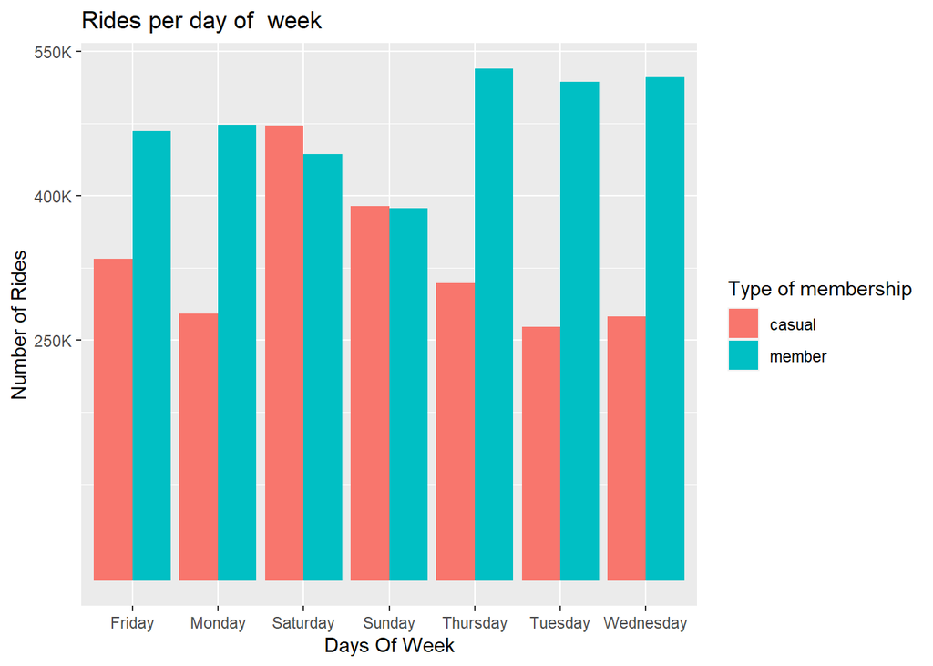

```r
trips22$day_of_week <- format(as.Date(trips22$date),"%A")
trips22 %>%
  group_by(member_casual,day_of_week) %>%
  summarise(number_of_rides = n()) %>%
  arrange(member_casual,day_of_week) %>%
  ggplot(aes(x=day_of_week,y=number_of_rides,fill=member_casual))+
  geom_col(position = 'dodge')+
  labs(x="Days Of Week", y="Number of Rides", title = "Rides per day of  week",fill="Type of membership")+
  scale_y_continuous(breaks=c(250000, 400000, 550000),labels=c("250K","400K","550K"))
```

####### The rides per day of week show casual riders peak on the Saturday and Sunday while members peak Monday through Friday. This indicates members mainly use the bikes for their commutes and not leisure.

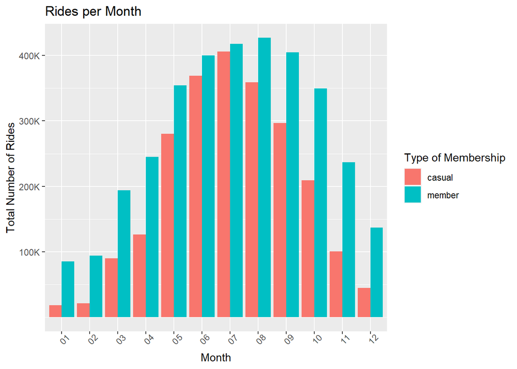

```r
trips22 %>%   #total rides broken down by month
  group_by(member_casual, month) %>%
  summarise(total_rides = n(),`average_duration_(mins)` = mean(ride_length)) %>%
  arrange(member_casual) %>%
  ggplot(aes(x=month, y=total_rides, fill = member_casual)) + geom_col(position = "dodge") +
  labs(x= "Month", y= "Total Number of Rides", title = "Rides per Month", fill = "Type of Membership") +
  scale_y_continuous(breaks = c(100000, 200000, 300000, 400000), labels = c("100K", "200K", "300K", "400K")) + theme(axis.text.x = element_text(angle = 45))
```

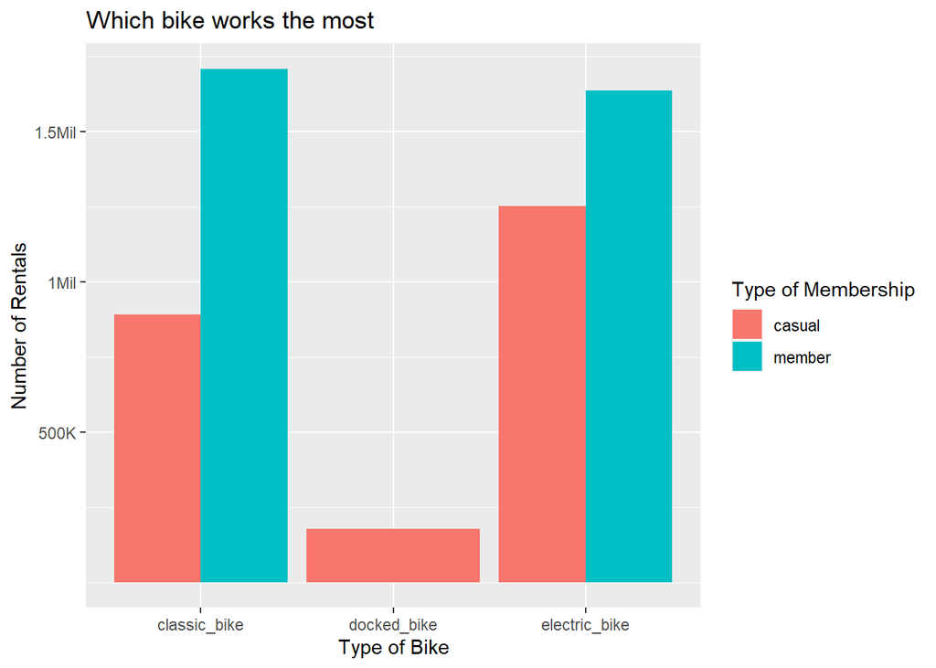

```r
trips22 %>%    #looking at breakdown of bike types rented
  ggplot(aes(x = rideable_type, fill = member_casual)) + geom_bar(position = "dodge") +
  labs(x= 'Type of Bike', y='Number of Rentals', title='Which bike works the most', fill = 'Type of Membership') +
  scale_y_continuous(breaks = c(500000, 1000000, 1500000), labels = c("500K", "1Mil", "1.5Mil"))
```

[figure not shown]

```r
trips22 %>%        #Find the average time spent riding by each membership type per individul day
  mutate(day_of_week = wday(started_at, label = TRUE)) %>%
  group_by(member_casual, day_of_week) %>%
  summarise(number_of_rides = n()
            ,average_duration = mean(ride_length)) %>%
  arrange(member_casual, day_of_week)  %>%
  ggplot(aes(x = day_of_week, y = average_duration, fill = member_casual)) +
  geom_col(position = "dodge") + labs(x='Days of the week', y='Average duration - Hrs', title='Average ride time per week', fill='Type of Membership')
```

The average ride time shows a stark difference between the casuals and members. Casuals overall spend more time using the service than their full time member counter-parts.

#### Recommendations

This report recommends the following: *Introducing plans thats may be more appealing to casuals for the summer months. This marketing should be done during the winter months in preperation.* The casual users might be more interested in a memebrship option that allows for per-use balance card. Alternatively, the existing payment structure may be altered in order to make single-use more costly to the casual riders as well as lowering the long-term membership rate. *Membership rates specifically for the warmer months as well as for those who only ride on the weekends would assist in targeting the casual riders more specifically

#### Things to consider

##### Additional points that were not examined

The report understands the scope of this analysis is extremely limited and because of that fact, additional data, as well as data points may have been able to contribute to this report offering an even more granular analysis. The following are data points that could have enhanced the report:

*Age and gender: This would add a dynamic to whether or not customers are being targeted across demograpic lines. Is the existing marketing effective? Is there potential for more inclusive targeting?* Pricing structure: THe actual pricing plans data was not provided and would give further insight to which plans are the most popular and by (how much) when comparing them. It would also be effective to understanding the spending behaviour of casual user. *Household income data: Pinpointing the average income of the long-term memebrs as compared to the casual counter-parts would allow for further analysis of what is the typical economic standing of each type of member, as well as providing the ability to analysis overall price sensitivity between the two different membership types.